# IE 582 - HW2 - Gestures

```python
import matplotlib.pyplot as plt
import numpy as np
import pandas as pd
import random as rd
from matplotlib import pyplot
from mpl_toolkits.mplot3d import Axes3D
import random
from sklearn.decomposition import PCA
from sklearn.preprocessing import StandardScaler
from sklearn.manifold import MDS
from sklearn.metrics.pairwise import manhattan_distances
```

```python
dfx = pd.read_csv('uWaveGestureLibrary_X_TRAIN', header = None, delimiter = r"\s+")
dfy = pd.read_csv('uWaveGestureLibrary_Y_TRAIN', header = None, delimiter = r"\s+")
dfz = pd.read_csv('uWaveGestureLibrary_Z_TRAIN', header = None, delimiter = r"\s+")
dfx['Time Series ID'] = range(1, len(dfx) + 1)
dfy['Time Series ID'] = range(1, len(dfy) + 1)
dfz['Time Series ID'] = range(1, len(dfz) + 1)
df = pd.concat([dfx.iloc[:, 0:316], dfy.iloc[:, 1:316], dfz.iloc[:, 1:316]], axis = 1, sort=False)
df.head(5)
```

|  | 0 | 1 | 2 | 3 | 4 | 5 | 6 | 7 | 8 | 9 | ... | 306 | 307 | 308 | 309 | 310 | 311 | 312 | 313 | 314 | 315 |
| --- | --- | --- | --- | --- | --- | --- | --- | --- | --- | --- | --- | --- | --- | --- | --- | --- | --- | --- | --- | --- | --- |
| 0 | 6.0 | -0.304243 | -0.304243 | -0.304243 | -0.304243 | -0.304243 | -0.304243 | -0.304243 | -0.304243 | -0.304243 | ... | 0.523217 | 0.513994 | 0.503481 | 0.492967 | 0.474522 | 0.456077 | 0.437632 | 0.419187 | 0.400743 | 0.382298 |
| 1 | 5.0 | 1.627311 | 1.627311 | 1.627311 | 1.627311 | 1.627311 | 1.627311 | 1.627311 | 1.627311 | 1.627311 | ... | -0.427010 | -0.427010 | -0.427010 | -0.427172 | -0.428773 | -0.440720 | -0.452667 | -0.464613 | -0.476560 | -0.488507 |
| 2 | 5.0 | 0.661277 | 0.661277 | 0.661277 | 0.661277 | 0.661277 | 0.661277 | 0.661277 | 0.661277 | 0.661277 | ... | -0.862717 | -0.862717 | -0.862717 | -0.862717 | -0.862717 | -0.862717 | -0.862717 | -0.862717 | -0.862717 | -0.862717 |
| 3 | 3.0 | 0.005185 | 0.005185 | 0.005185 | 0.005185 | 0.005185 | 0.005185 | 0.005185 | 0.005185 | 0.005185 | ... | -0.187384 | -0.123549 | -0.055870 | 0.011808 | 0.079487 | 0.157056 | 0.253740 | 0.445503 | 0.648538 | 0.851573 |
| 4 | 4.0 | 1.286198 | 1.286198 | 1.286198 | 1.286198 | 1.286198 | 1.286198 | 1.286198 | 1.286198 | 1.286198 | ... | 1.867472 | 1.834319 | 1.756000 | 1.638582 | 1.521164 | 1.453266 | 1.515219 | 1.632637 | 1.750054 | 1.867472 |

5 rows × 946 columns

# Section A: Visualization of the Data

## Task:

Read the data and visualize one instance (all axes) from each class and try to relate the shape (time series) you see with the gestures shown in Figure 1. A 3D scatter plot would be interesting. Note that this is an acceleration information. You can transform this information to a velocity vector by computing the cumulative sum of acceleration over time.

### Acceleration to Position

First of all, I cumulated the data two times over the time series to transform acceloration data to position data.

```python
c_dfx = dfx.iloc[:, 1:316].cumsum(axis=1).cumsum(axis=1)
c_dfy = dfy.iloc[:, 1:316].cumsum(axis=1).cumsum(axis=1)
c_dfz = dfz.iloc[:, 1:316].cumsum(axis=1).cumsum(axis=1)
c_df = pd.concat([dfx.iloc[:, 0:1], c_dfx.iloc[:, 0:315], c_dfy.iloc[:, 0:315], c_dfz.iloc[:, 0:316]], axis = 1, sort=False)
c_df['Time Series ID'] = range(1, len(c_df) + 1)
c_df.head(5)
```

|  | 0 | 1 | 2 | 3 | 4 | 5 | 6 | 7 | 8 | 9 | ... | 307 | 308 | 309 | 310 | 311 | 312 | 313 | 314 | 315 | Time Series ID |
| --- | --- | --- | --- | --- | --- | --- | --- | --- | --- | --- | --- | --- | --- | --- | --- | --- | --- | --- | --- | --- | --- |
| 0 | 6.0 | -0.304243 | -0.912730 | -1.825459 | -3.042432 | -4.563648 | -6.389107 | -8.518810 | -10.952756 | -13.690944 | ... | -22397.080506 | -22400.143932 | -22402.714390 | -22404.810326 | -22406.450185 | -22407.652411 | -22408.435450 | -22408.817746 | -22408.817745 | 1 |
| 1 | 5.0 | 1.627311 | 4.881933 | 9.763867 | 16.273111 | 24.409667 | 34.173533 | 45.564711 | 58.583200 | 73.229000 | ... | 21469.860898 | 21473.039910 | 21475.791750 | 21478.114817 | 21479.997165 | 21481.426845 | 21482.391912 | 21482.880419 | 21482.880418 | 2 |
| 2 | 5.0 | 0.661277 | 1.983830 | 3.967659 | 6.612765 | 9.919148 | 13.886807 | 18.515743 | 23.805955 | 29.757444 | ... | 23639.949883 | 23645.988903 | 23651.165206 | 23655.478792 | 23658.929660 | 23661.517812 | 23663.243246 | 23664.105963 | 23664.105963 | 3 |
| 3 | 3.0 | 0.005185 | 0.015554 | 0.031109 | 0.051848 | 0.077772 | 0.108880 | 0.145174 | 0.186652 | 0.233315 | ... | 5379.666500 | 5377.218796 | 5374.782899 | 5372.426489 | 5370.227135 | 5368.281520 | 5366.781408 | 5365.929835 | 5365.929835 | 4 |
| 4 | 4.0 | 1.286198 | 3.858593 | 7.717187 | 12.861978 | 19.292967 | 27.010154 | 36.013538 | 46.303121 | 57.878901 | ... | -16925.473284 | -16936.851680 | -16946.591494 | -16954.810144 | -16961.575528 | -16966.825694 | -16970.443222 | -16972.310696 | -16972.310698 | 5 |

5 rows × 947 columns

```python
c_dfx_class = pd.concat([dfx.iloc[:, 0:1], c_dfx.iloc[:, 0:315]], axis = 1, sort=False)
c_dfx_class['Time Series ID'] = range(1, len(c_dfx_class) + 1)
melt_dfx = pd.melt(c_dfx_class, id_vars=[dfx.columns[0],dfx.columns[316]], var_name='Time Series', value_name='X')
melt_dfy = pd.melt(c_dfy, var_name='Time Series', value_name='Y')
melt_dfz = pd.melt(c_dfz, var_name='Time Series', value_name='Z')
melt_dfx.rename(columns={0: 'Class'}, inplace=True)
melt_df = pd.concat([melt_dfx, melt_dfy.iloc[:, 1:2], melt_dfz.iloc[:, 1:2]], axis = 1, sort=False)

cols = list(melt_df.columns.values)
melt_df = melt_df[cols [1:6] + [cols[0]]]
melt_df = melt_df.sort_values(['Time Series ID','Time Series'])

melt_df.head(5)
```

|  | Time Series ID | Time Series | X | Y | Z | Class |
| --- | --- | --- | --- | --- | --- | --- |
| 0 | 1 | 1 | -0.304243 | -2.119396 | -1.528965 | 6.0 |
| 896 | 1 | 2 | -0.912730 | -6.358187 | -4.586895 | 6.0 |
| 1792 | 1 | 3 | -1.825459 | -12.716375 | -9.173791 | 6.0 |
| 2688 | 1 | 4 | -3.042432 | -21.193958 | -15.289651 | 6.0 |
| 3584 | 1 | 5 | -4.563648 | -31.790937 | -22.934477 | 6.0 |

### Visualization of Data: 3D Scatter Plot

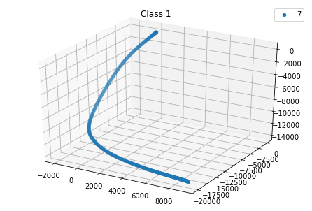

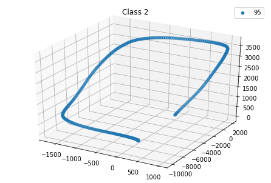

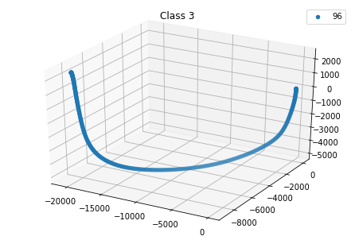

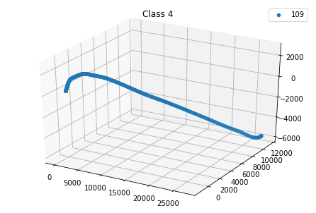

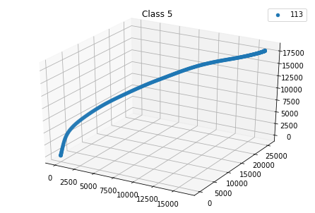

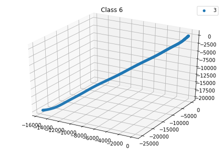

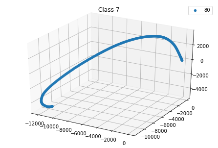

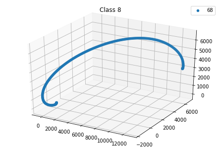

```python
cols_dfx = list(dfx.columns.values)
cl_tseries = dfx[[cols_dfx[0]] + [cols_dfx[316]]]

a = [1,2,3,4,5,6,7,8]

for i in a:
    cl_tseries_flt = cl_tseries.loc[(cl_tseries[0] == i)]
    b = rd.randint(0,cl_tseries_flt.shape[0]-1)

    new_df = melt_df.loc[(melt_df['Class'] == i) & (melt_df['Time Series ID']== cl_tseries_flt.iloc[b,1])]

    fig = pyplot.figure()
    ax = Axes3D(fig)
    ax.scatter(new_df["X"], new_df["Y"], new_df["Z"], label = b)
    ax.set_title("Class {}".format(i))
    plt.legend()
    pyplot.show()
```

# Section B: Application of PCA

## Task:

Suppose our aim is to reduce this multivariate time series to a univariate one with a dimensionality reduction approach. Suppose we decide to reduce the data from 3D (i.e. X, Y and Z features) to 1D using PCA. Relevant columns for PCA is X, Y and Z. Apply PCA to the whole data (regardless of the time series id or class) and report PCA results.

Select 2 random time series from each class and visualize the reduced dimensions as time series in a single plot to see if classes can be separated in the reduced dimensions.

### Data Standardization and PCA

```python
xyz_df = melt_df.drop(['Time Series ID', 'Time Series', 'Class'], axis=1) # drop categorical features
scaler = StandardScaler()
scaler.fit(xyz_df)
scaled_data = scaler.transform(xyz_df)
scaled_data
```

```
array([[-0.07050426,  0.07936499, -0.03212954],
       [-0.07056922,  0.07896996, -0.03244724],
       [-0.07066665,  0.07837742, -0.03292379],
       ...,
       [ 0.16371224,  2.27557206,  2.35605877],
       [ 0.16352138,  2.27563005,  2.35613532],
       [ 0.16352138,  2.27563005,  2.35613532]])
```

```python
#3D to 1D Reduction
pca = PCA(n_components=3)
pca.fit(scaled_data)
pca_df = pca.transform(scaled_data)
pca_df
#rows = len(pca_df)
```

```
array([[ 2.14915983e-02, -4.27056414e-02,  1.00081465e-01],
       [ 2.09832230e-02, -4.26777162e-02,  1.00037043e-01],
       [ 2.02206600e-02, -4.26358284e-02,  9.99704090e-02],
       ...,
       [ 3.23064028e+00, -5.64803043e-01, -1.92483461e-03],
       [ 3.23069266e+00, -5.65001292e-01, -1.86480957e-03],
       [ 3.23069266e+00, -5.65001292e-01, -1.86480956e-03]])
```

```python
print(pca.explained_variance_ratio_)
print(pca.singular_values_)
```

```
[0.53975165 0.35921237 0.10103597]
[676.03144893 551.50004586 292.48791339]
```

The first component of PCA contains highest explained variance ratio (0.539). I reduced 3D data to 1D data by using the first component.

```python
melt1D_df = melt_df.copy()
melt1D_df['X_STD'] = scaled_data[:,0]
melt1D_df['Y_STD'] = scaled_data[:,1]
melt1D_df['Z_STD'] = scaled_data[:,2]
melt1D_df['1D'] = pca_df[:,0]
melt1D_df.head(5)
```

|  | Time Series ID | Time Series | X | Y | Z | Class | X_STD | Y_STD | Z_STD | 1D |
| --- | --- | --- | --- | --- | --- | --- | --- | --- | --- | --- |
| 0 | 1 | 1 | -0.304243 | -2.119396 | -1.528965 | 6.0 | -0.070504 | 0.079365 | -0.032130 | 0.021492 |
| 896 | 1 | 2 | -0.912730 | -6.358187 | -4.586895 | 6.0 | -0.070569 | 0.078970 | -0.032447 | 0.020983 |
| 1792 | 1 | 3 | -1.825459 | -12.716375 | -9.173791 | 6.0 | -0.070667 | 0.078377 | -0.032924 | 0.020221 |
| 2688 | 1 | 4 | -3.042432 | -21.193958 | -15.289651 | 6.0 | -0.070797 | 0.077587 | -0.033559 | 0.019204 |
| 3584 | 1 | 5 | -4.563648 | -31.790937 | -22.934477 | 6.0 | -0.070959 | 0.076600 | -0.034353 | 0.017933 |

### Visualization

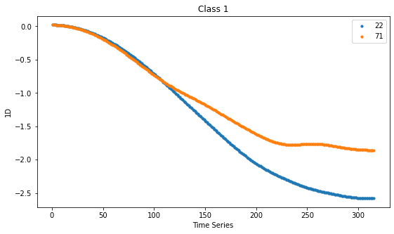

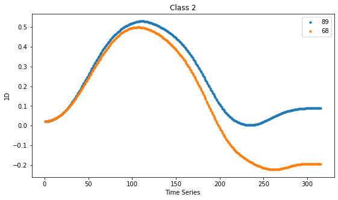

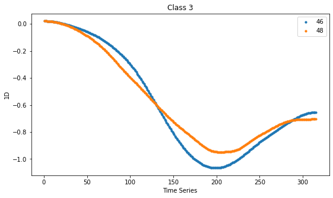

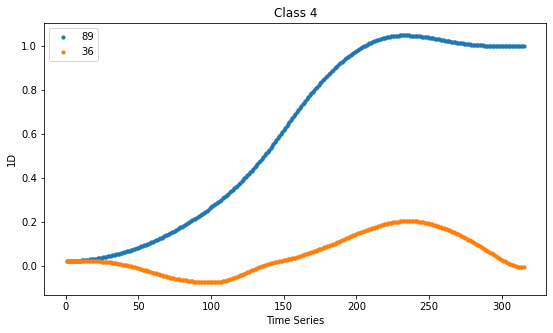

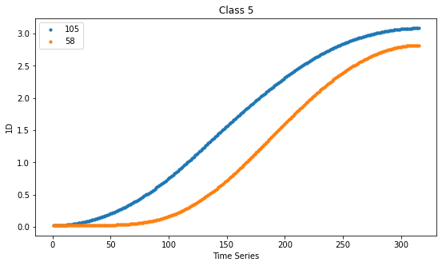

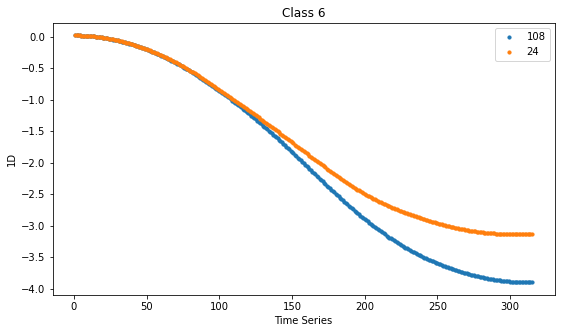

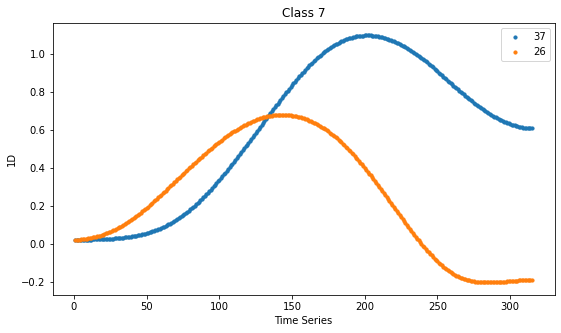

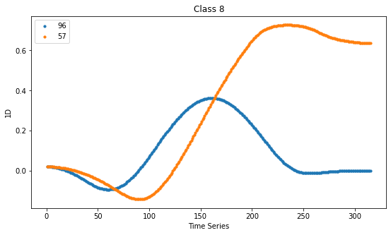

```python
for i in a:
    cl_tseries_flt = cl_tseries.loc[(cl_tseries[0] == i)]
    b = rd.randint(0,cl_tseries_flt.shape[0]-1)
    c = rd.randint(0,cl_tseries_flt.shape[0]-1)

    plt.figure(figsize=(9,5))

    new1D_1_df = melt1D_df.loc[(melt_df['Class'] == i) & (melt1D_df['Time Series ID']== cl_tseries_flt.iloc[b,1])]
    new1D_2_df = melt1D_df.loc[(melt_df['Class'] == i) & (melt1D_df['Time Series ID']== cl_tseries_flt.iloc[c,1])]
    plt.scatter(new1D_1_df["Time Series"], new1D_1_df["1D"], s = 10, label = b)
    plt.scatter(new1D_1_df["Time Series"], new1D_2_df["1D"], s = 10, label = c)

    plt.xticks()
    plt.ylabel('1D')
    plt.xlabel('Time Series')
    plt.title("Class {}".format(i))
    loc='upper right'
    bbox_to_anchor=(0.5, 0.5)
    plt.legend()
    plt.show()
```

Both of the instances in class 1 follow similar paths. There are also similar results in class 6 so it might be a little bit harder to separate class 1 and class 6. However, class 6 seems to be ended smoothly compared to class 1. In the figure 1, both class 1 and class 6 gestures go down and this may explain the similarities between them.

In class 2, instances follows a specific path which can be easily separated by others. It started with a concave shape and then turned into convex. It can be easily differentiated from other classes.

Instances in class 3 and class 4 seems to be vice versa. It is logical because class 3 gesture is a move that goes left-to-right and class 4 gesture is a move that goes right-to-left. It is possible to spereate them by visual inspection.

Instances in class 5 and class 6 are also vice versa with the similar reason of class 3 and 4. It is possible to seperate them from other classes by visual inspection.

Class 7 and class 8 seems similar with slight differences. Small pit at the beginning of class 8 may provide some vision for classification.

As a result, mostly, it seems possible to classify instances and separate classes with visualization of the 1D data.

# Section C: Application of PCA for Each Class

## Task:

Report PCA results (components, variance covered by each component). Is there any interesting observation on the first component of the PCA results applied to the data from each class? Are the first components similar? Comment on your findings.

```python
for i in a:
    cl_melt_df = melt_df.loc[(melt_df['Class'] == i)]
    cl_xyz_df = cl_melt_df.drop(['Time Series ID', 'Time Series', 'Class'], axis=1) # drop categorical features
    cl_scaler = StandardScaler()
    cl_scaler.fit(cl_xyz_df)
    cl_scaled_data = cl_scaler.transform(cl_xyz_df)
    cl_scaled_data

    #3D to 1D Reduction
    cl_pca = PCA(n_components=3)
    cl_pca.fit(cl_scaled_data)
    cl_pca_df = pca.transform(cl_scaled_data)
    print()
    print("Class {}".format(i))
    print("PCA Components")
    print(cl_pca.components_)
    print("Explained Variance Ratio")
    print(cl_pca.explained_variance_ratio_)
    print("Singular Values")
    print(cl_pca.singular_values_)

    #rows = len(pca_df)
```

```
Class 1
PCA Components
[[ 0.11927821  0.69326886  0.71073976]
 [ 0.97300528 -0.22406752  0.05526735]
 [ 0.19756882  0.68496134 -0.70128063]]
Explained Variance Ratio
[0.55749784 0.33945939 0.10304276]
Singular Values
[253.52302945 197.8288988  108.99449682]

Class 2
PCA Components
[[-0.53539644 -0.61261432 -0.58142441]
 [-0.81436908  0.19190574  0.54769991]
 [ 0.22395013 -0.76673064  0.60163981]]
Explained Variance Ratio
[0.42461971 0.2981175  0.2772628 ]
Singular Values
[208.17465561 174.4301344  168.21843234]

Class 3
PCA Components
[[-0.70913558 -0.37141705  0.59931303]
 [ 0.00558168  0.84701853  0.53153406]
 [-0.70505006  0.38027489 -0.59857784]]
Explained Variance Ratio
[0.49260077 0.3351846  0.17221463]
Singular Values
[222.1346877  183.23602529 131.34207078]

Class 4
PCA Components
[[ 0.70188893  0.67403846 -0.23026959]
 [ 0.04016825  0.28531139  0.95759278]
 [-0.7111529   0.6813733  -0.17318196]]
Explained Variance Ratio
[0.55090369 0.32768379 0.12141253]
Singular Values
[239.30407048 184.56091085 112.34247655]

```

[output cut: 24 more lines]

```
 [-0.63878174  0.74706197 -0.18400081]]
Explained Variance Ratio
[0.56090255 0.26307711 0.17602034]
Singular Values
[243.65123886 166.86545737 136.49173213]

Class 8
PCA Components
[[ 0.66373042  0.33671128  0.66789779]
 [-0.25272822  0.94138484 -0.22343462]
 [ 0.70398181  0.02049627 -0.70992219]]
Explained Variance Ratio
[0.49638855 0.31254071 0.19107074]
Singular Values
[216.58420533 171.85778113 134.37330489]
```

With the comparation of first component for each class, it is obvious that dominant weights of the ach axis on the first component are different. Moreoever, the PCA applied to the whole data is resulted in explained variance ratio value as 0.539. However, when pca is applied to each class one by one, explained variance ratio value is higher than whole data’s value in class 1, 4, 5, 6 and 7. Therefore, usefulness in these classes is increased.

# Section D

## Task:

Suppose, our aim now is to visualize the time series in reduced dimensions for classification purposes. Assume that we compute the distance between the time series for each axis using the original representation (i.e. a row represents individual time series, column is the time index and entries are the observations) over each axis and sum them up to obtain a final distance measure. You are expected to obtain a symmetric distance matrix. Let’s apply multi-dimensional scaling to this distance matrix to represent each time series on a 2-dimensional feature space. Visualize the observations using the reduced features and color-code the points with the class information. Comment on your findings.

### Symmetric Distance Matrix

```python
dist_x = manhattan_distances(dfx.iloc[:, 1:316])
dist_y = manhattan_distances(dfy.iloc[:, 1:316])
dist_z = manhattan_distances(dfz.iloc[:, 1:316])
dist = dist_x + dist_y + dist_z
dist = pd.DataFrame(dist)
dist
#print(dist.shape)
```

|  | 0 | 1 | 2 | 3 | 4 | 5 | 6 | 7 | 8 | 9 | ... | 886 | 887 | 888 | 889 | 890 | 891 | 892 | 893 | 894 | 895 |
| --- | --- | --- | --- | --- | --- | --- | --- | --- | --- | --- | --- | --- | --- | --- | --- | --- | --- | --- | --- | --- | --- |
| 0 | 0.000000 | 1378.067323 | 1253.542426 | 1347.464453 | 1098.296970 | 1240.982409 | 1192.746492 | 812.640236 | 974.385458 | 714.344616 | ... | 1134.270005 | 1051.749556 | 1084.560222 | 863.567747 | 1434.006773 | 921.903412 | 992.617763 | 1079.327112 | 1186.306431 | 1432.856153 |
| 1 | 1378.067323 | 0.000000 | 665.992225 | 838.273806 | 816.571010 | 976.471033 | 967.509338 | 1325.635567 | 970.937791 | 1635.469953 | ... | 1142.415221 | 1325.205305 | 832.982445 | 1325.485842 | 752.483923 | 1167.646031 | 1454.611277 | 1020.408718 | 1072.971873 | 560.815256 |
| 2 | 1253.542426 | 665.992225 | 0.000000 | 1031.407155 | 799.602868 | 894.933742 | 1405.780683 | 1171.222015 | 943.551493 | 1560.120750 | ... | 1282.685245 | 1122.142779 | 786.938731 | 1296.311326 | 884.113565 | 907.015885 | 1269.148256 | 1172.536719 | 1356.941908 | 543.249534 |
| 3 | 1347.464453 | 838.273806 | 1031.407155 | 0.000000 | 1120.790564 | 1001.080861 | 993.837137 | 1431.655659 | 1225.029823 | 1213.504993 | ... | 930.690012 | 938.209559 | 1151.221315 | 1188.899707 | 781.505965 | 1045.921426 | 1198.800310 | 824.492110 | 940.265496 | 832.989374 |
| 4 | 1098.296970 | 816.571010 | 799.602868 | 1120.790564 | 0.000000 | 982.506911 | 1157.557069 | 879.575240 | 474.780325 | 1353.224658 | ... | 1196.682051 | 1398.879084 | 382.713099 | 936.005525 | 1310.411176 | 1129.546353 | 1132.406688 | 1141.636182 | 1116.187526 | 1014.326480 |
| ... | ... | ... | ... | ... | ... | ... | ... | ... | ... | ... | ... | ... | ... | ... | ... | ... | ... | ... | ... | ... | ... |
| 891 | 921.903412 | 1167.646031 | 907.015885 | 1045.921426 | 1129.546353 | 1175.664609 | 1126.721677 | 1035.091955 | 1258.016214 | 1047.840137 | ... | 1099.857487 | 792.890419 | 1168.628789 | 1163.861083 | 1008.849751 | 0.000000 | 1115.925415 | 1089.819760 | 1119.325237 | 1107.627946 |
| 892 | 992.617763 | 1454.611277 | 1269.148256 | 1198.800310 | 1132.406688 | 964.409883 | 1139.955114 | 842.966081 | 1061.108139 | 903.065025 | ... | 1070.894190 | 999.570602 | 1128.508668 | 909.616376 | 1327.760491 | 1115.925415 | 0.000000 | 1061.815821 | 964.819372 | 1298.665056 |
| 893 | 1079.327112 | 1020.408718 | 1172.536719 | 824.492110 | 1141.636182 | 1114.482358 | 919.845178 | 1153.211896 | 1134.691477 | 1192.855645 | ... | 1104.366450 | 1071.215837 | 1127.018068 | 954.084566 | 1128.986300 | 1089.819760 | 1061.815821 | 0.000000 | 914.298019 | 1078.901825 |
| 894 | 1186.306431 | 1072.971873 | 1356.941908 | 940.265496 | 1116.187526 | 1264.661333 | 468.391444 | 1088.636981 | 1102.107261 | 1087.797934 | ... | 857.945133 | 1119.014942 | 1052.089307 | 955.767750 | 1176.278209 | 1119.325237 | 964.819372 | 914.298019 | 0.000000 | 1253.878416 |
| 895 | 1432.856153 | 560.815256 | 543.249534 | 832.989374 | 1014.326480 | 794.826545 | 1258.348694 | 1334.697828 | 1058.781881 | 1542.933032 | ... | 1178.159823 | 1171.220467 | 973.981372 | 1364.956962 | 629.355271 | 1107.627946 | 1298.665056 | 1078.901825 | 1253.878416 | 0.000000 |

896 rows × 896 columns

I used manhattan distances to find out distance matrix because of the size of the data(dimensions).

```python
dist_x = manhattan_distances(c_dfx.iloc[:, 0:316])
dist_y = manhattan_distances(c_dfy.iloc[:, 0:316])
dist_z = manhattan_distances(c_dfz.iloc[:, 0:316])
dist = dist_x + dist_y + dist_z
dist = pd.DataFrame(dist)
dist.head(10)
#print(dist.shape)
```

|  | 0 | 1 | 2 | 3 | 4 | 5 | 6 | 7 | 8 | 9 | ... | 886 | 887 | 888 | 889 | 890 | 891 | 892 | 893 | 894 | 895 |
| --- | --- | --- | --- | --- | --- | --- | --- | --- | --- | --- | --- | --- | --- | --- | --- | --- | --- | --- | --- | --- | --- |
| 0 | 0.000000e+00 | 1.892970e+07 | 1.489553e+07 | 1.266741e+07 | 1.082601e+07 | 9.526314e+06 | 1.234209e+07 | 5.196159e+06 | 1.044392e+07 | 5.750640e+06 | ... | 8.725462e+06 | 8.929930e+06 | 1.206941e+07 | 3.435963e+06 | 2.094797e+07 | 9.658339e+06 | 4.634318e+06 | 8.468898e+06 | 8.896252e+06 | 1.516523e+07 |
| 1 | 1.892970e+07 | 0.000000e+00 | 4.290775e+06 | 1.077864e+07 | 9.714901e+06 | 1.004165e+07 | 7.156000e+06 | 1.373354e+07 | 9.696106e+06 | 2.423163e+07 | ... | 1.097093e+07 | 1.525741e+07 | 8.150701e+06 | 1.719687e+07 | 9.131509e+06 | 1.249425e+07 | 1.767374e+07 | 1.067051e+07 | 1.006583e+07 | 3.996371e+06 |
| 2 | 1.489553e+07 | 4.290775e+06 | 0.000000e+00 | 7.815531e+06 | 7.443661e+06 | 6.023677e+06 | 6.501704e+06 | 1.003340e+07 | 9.613611e+06 | 2.019747e+07 | ... | 7.549704e+06 | 1.122325e+07 | 5.532556e+06 | 1.316270e+07 | 1.086006e+07 | 8.460075e+06 | 1.363957e+07 | 7.306298e+06 | 6.775800e+06 | 4.430077e+06 |
| 3 | 1.266741e+07 | 1.077864e+07 | 7.815531e+06 | 0.000000e+00 | 1.073723e+07 | 4.948896e+06 | 4.881149e+06 | 1.131650e+07 | 1.214033e+07 | 1.345300e+07 | ... | 4.305615e+06 | 5.404539e+06 | 8.633653e+06 | 1.338288e+07 | 8.290912e+06 | 3.552459e+06 | 9.133459e+06 | 4.474866e+06 | 4.327993e+06 | 6.948174e+06 |
| 4 | 1.082601e+07 | 9.714901e+06 | 7.443661e+06 | 1.073723e+07 | 0.000000e+00 | 1.001485e+07 | 9.043938e+06 | 5.639071e+06 | 3.392175e+06 | 1.612794e+07 | ... | 9.367565e+06 | 1.361064e+07 | 2.344628e+06 | 9.093956e+06 | 1.830372e+07 | 1.068210e+07 | 9.624106e+06 | 8.227216e+06 | 8.558787e+06 | 1.176726e+07 |
| 5 | 9.526314e+06 | 1.004165e+07 | 6.023677e+06 | 4.948896e+06 | 1.001485e+07 | 0.000000e+00 | 5.398538e+06 | 8.126691e+06 | 1.257610e+07 | 1.418999e+07 | ... | 2.893018e+06 | 5.908766e+06 | 7.670223e+06 | 9.934711e+06 | 1.173908e+07 | 3.129197e+06 | 7.956252e+06 | 3.239141e+06 | 2.670282e+06 | 6.264383e+06 |
| 6 | 1.234209e+07 | 7.156000e+06 | 6.501704e+06 | 4.881149e+06 | 9.043938e+06 | 5.398538e+06 | 0.000000e+00 | 1.062414e+07 | 9.356334e+06 | 1.764402e+07 | ... | 4.393711e+06 | 1.009546e+07 | 7.157188e+06 | 1.259842e+07 | 9.506367e+06 | 6.954379e+06 | 1.108612e+07 | 4.119967e+06 | 3.478215e+06 | 4.352081e+06 |
| 7 | 5.196159e+06 | 1.373354e+07 | 1.003340e+07 | 1.131650e+07 | 5.639071e+06 | 8.126691e+06 | 1.062414e+07 | 0.000000e+00 | 6.062775e+06 | 1.049809e+07 | ... | 7.539819e+06 | 1.054658e+07 | 6.886443e+06 | 4.865428e+06 | 1.960742e+07 | 8.335405e+06 | 5.039825e+06 | 6.926818e+06 | 7.370629e+06 | 1.307095e+07 |
| 8 | 1.044392e+07 | 9.696106e+06 | 9.613611e+06 | 1.214033e+07 | 3.392175e+06 | 1.257610e+07 | 9.356334e+06 | 6.062775e+06 | 0.000000e+00 | 1.573982e+07 | ... | 1.142979e+07 | 1.616807e+07 | 5.067742e+06 | 9.931037e+06 | 1.786092e+07 | 1.324335e+07 | 1.074582e+07 | 1.004592e+07 | 1.043904e+07 | 1.132446e+07 |
| 9 | 5.750640e+06 | 2.423163e+07 | 2.019747e+07 | 1.345300e+07 | 1.612794e+07 | 1.418999e+07 | 1.764402e+07 | 1.049809e+07 | 1.573982e+07 | 0.000000e+00 | ... | 1.326087e+07 | 8.974220e+06 | 1.737134e+07 | 7.512378e+06 | 1.727016e+07 | 1.173739e+07 | 6.589097e+06 | 1.356128e+07 | 1.416581e+07 | 2.039185e+07 |

10 rows × 896 columns

```python
dfx.shape
embedding = MDS(n_components=2)
X_transformed = embedding.fit_transform(dist)
X_transformed
```

```
array([[ 8.66647381e+07, -1.05758940e+08],
       [-1.89369652e+08, -2.55154608e+07],
       [-1.07121641e+08,  1.32632314e+07],
       ...,
       [ 2.25892883e+07,  7.81330890e+07],
       [ 1.53316137e+07,  8.01503549e+07],
       [-1.24625556e+08,  3.92866406e+07]])
```

### Multi-Dimensional Scaling

```python
MDS_df = pd.DataFrame(X_transformed)
MDS_df['Class']= dfx.iloc[:,0:1]
MDS_df.rename(columns={0: "Dim1", 1: "Dim2"}, inplace=True)
MDS_df
```

|  | Dim1 | Dim2 | Class |
| --- | --- | --- | --- |
| 0 | 8.666474e+07 | -1.057589e+08 | 6.0 |
| 1 | -1.893697e+08 | -2.551546e+07 | 5.0 |
| 2 | -1.071216e+08 | 1.326323e+07 | 5.0 |
| 3 | -1.924655e+07 | 8.910342e+07 | 3.0 |
| 4 | -5.597242e+07 | -6.727296e+07 | 4.0 |
| ... | ... | ... | ... |
| 891 | 4.169424e+07 | 5.884809e+07 | 3.0 |
| 892 | 9.367335e+07 | -3.861670e+07 | 1.0 |
| 893 | 2.258929e+07 | 7.813309e+07 | 2.0 |
| 894 | 1.533161e+07 | 8.015035e+07 | 7.0 |
| 895 | -1.246256e+08 | 3.928664e+07 | 5.0 |

896 rows × 3 columns

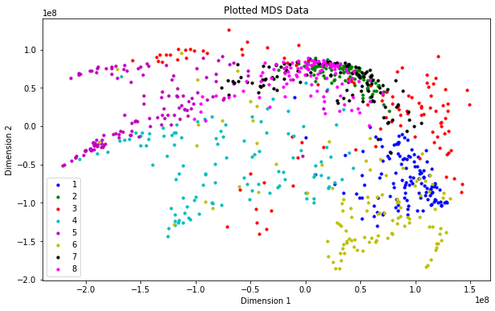

```python
cl1 = MDS_df.loc[(MDS_df['Class'] == 1)]
cl2 = MDS_df.loc[(MDS_df['Class'] == 2)]
cl3 = MDS_df.loc[(MDS_df['Class'] == 3)]
cl4 = MDS_df.loc[(MDS_df['Class'] == 4)]
cl5 = MDS_df.loc[(MDS_df['Class'] == 5)]
cl6 = MDS_df.loc[(MDS_df['Class'] == 6)]
cl7 = MDS_df.loc[(MDS_df['Class'] == 7)]
cl8 = MDS_df.loc[(MDS_df['Class'] == 8)]

plt.figure(figsize=(10,6))
plt.scatter(cl1.Dim1, cl1.Dim2, c = 'b', label = '1' , s = 10)
plt.scatter(cl2.Dim1, cl2.Dim2, c = 'g', label = '2' , s = 10)
plt.scatter(cl3.Dim1, cl3.Dim2, c = 'r', label = '3' , s = 10)
plt.scatter(cl4.Dim1, cl4.Dim2, c = 'c', label = '4' , s = 10)
plt.scatter(cl5.Dim1, cl5.Dim2, c = 'm', label = '5' , s = 10)
plt.scatter(cl6.Dim1, cl6.Dim2, c = 'y', label = '6' , s = 10)
plt.scatter(cl7.Dim1, cl7.Dim2, c = 'k', label = '7' , s = 10)
plt.scatter(cl8.Dim1, cl8.Dim2, c = 'fuchsia', label = '8' , s = 10)
cl_obj = [1,2,3,4,5,6,7,8]
plt.xlabel('Dimension 1')
plt.ylabel('Dimension 2')
plt.title('Plotted MDS Data')
plt.legend()
plt.show()
```

With the visualization of the data, classes seems to be focused on different location on the plot. Especially, class 5, 6 and 4 are seperable.

I also would like to see if vice versa gestures have similar or different results.

Reduced datas in class 3 are mostly on right hand side of 0 value and upper side of value 0 in dimension 1 and 2, respectively. Reduced datas in class 4 seems to be opposite of class 3. It may be concluded by the effect of direction of the movement.

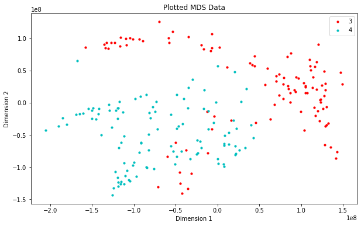

```python
plt.figure(figsize=(10,6))
plt.scatter(cl3.Dim1, cl3.Dim2, c = 'r', label = '3' , s = 10)
plt.scatter(cl4.Dim1, cl4.Dim2, c = 'c', label = '4' , s = 10)
cl_obj = [1,2,3,4,5,6,7,8]
plt.xlabel('Dimension 1')
plt.ylabel('Dimension 2')
plt.title('Plotted MDS Data')
plt.legend()
plt.show()
```

For class 5 and 6, reduced datas in each class seems to be dispersed symmetrically considering a diagonal from lower left corner to upper right corner. They are both distinguisbalbe as classes. Moreover it is easier to differentiate them from other classes.

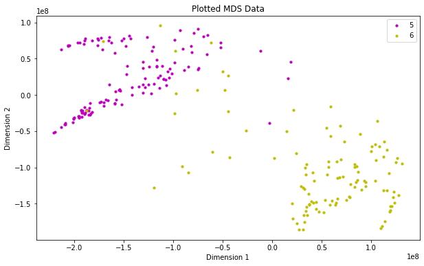

```python
plt.figure(figsize=(10,6))
plt.scatter(cl5.Dim1, cl5.Dim2, c = 'm', label = '5' , s = 10)
plt.scatter(cl6.Dim1, cl6.Dim2, c = 'y', label = '6' , s = 10)
cl_obj = [1,2,3,4,5,6,7,8]
plt.xlabel('Dimension 1')
plt.ylabel('Dimension 2')
plt.title('Plotted MDS Data')
plt.legend()
plt.show()
```

Movements of class 7 and 8 are quite similar as they start and end at the same point even though they follow different direction. Therefore, it is logical that they are not distinguishable as the reduced datas.

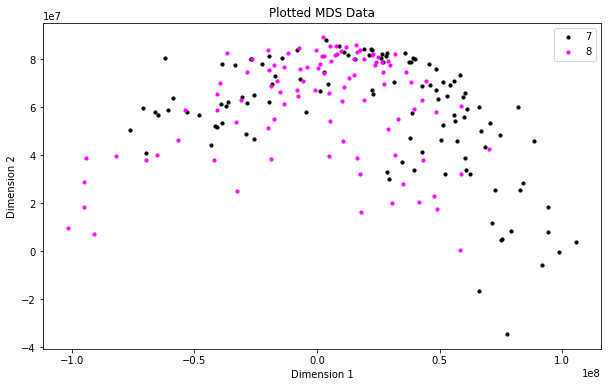

```python
plt.figure(figsize=(10,6))
plt.scatter(cl7.Dim1, cl7.Dim2, c = 'k', label = '7' , s = 10)
plt.scatter(cl8.Dim1, cl8.Dim2, c = 'fuchsia', label = '8' , s = 10)
cl_obj = [1,2,3,4,5,6,7,8]
plt.xlabel('Dimension 1')
plt.ylabel('Dimension 2')
plt.title('Plotted MDS Data')
plt.legend()
plt.show()
```